# QTM 385 Final Project

Prerna Advani

# Research Topic

**Impact of randomization on social welfare and electoral system outcomes**

# Process

- Part 1:
  - Dataset 1: In my theoretical society, there will be five candidates in the race for one elected position and fifteen voters. First, I will create a matrix where each voter randomly assigns each candidate a score between 0-100, thus using a score voting system. Using these scores, I will calculate social welfare outcomes through the Benthamite, Rawlsian, and Egalitarian winners.
  - Dataset 2: Using the same numbers from Dataset 1, I will adjust the scores for intensity of preference by dividing each score by the total number of points allotted by each voter and multiplying by 100. Essentially, the matrix will now demonstrate preferences such that each voter has 100 total points that must be distributed between the 5 candidates. I will recalculate winners for each of the social welfare functions. Next, I will calculate winners based on SMP, Borda Count, and Instant Runoff.
- Part 2:
  - Dataset 3: In the second part of my code, I will randomly create fake profiles for each of the five candidates and analyze preferences from real people. I will gather preferences from six women that are students at Emory University, in Delta Phi Epsilon sorority, and were raised in the state of Georgia. I will recalculate social welfare functions and electoral system results based on their preference.
- After gathering this data, I will compare the variability in results from computerized preferences and human preferences and analyze outcomes.

# Data

## Part 1: Computerized Dataset

### Social Welfare Functions

> Raw randomized scores
- Number of voters: 15
- Number of candidates: 5
- Data: randomly assigned scores between 0-100

```r
set.seed(385)
prefs = matrix(sample(0:100,15*5, replace=TRUE),15,5)
colnames(prefs) <- c("Candidate A","Candidate B", "Candidate C", "Candidate D", "Candidate E")
prefs
```

```
##       Candidate A Candidate B Candidate C Candidate D Candidate E
##  [1,]          82          34          18          20          93
##  [2,]          43          67          60          37          55
##  [3,]          88          71           3          79          36
##  [4,]         100          78          36           7          87
##  [5,]          35          14          86          36          89
##  [6,]          72         100          37          70          89
##  [7,]          27          71          65          66          74
##  [8,]          97          24          56          41          55
##  [9,]          21          48          33          49           2
## [10,]          48          15          35          63          94
## [11,]          27           9          71          87          64
## [12,]          72          13           4          52          15
## [13,]          78          55          61          31          93
## [14,]           2          23          42          33          42
## [15,]          48          11          59          94          17
```

```r
#average score
sum(prefs)/75
```

```
## [1] 50.78667
```

```r
#Highest total
as.matrix(colSums(prefs))
```

```
##             [,1]
## Candidate A  840
## Candidate B  633
## Candidate C  666
## Candidate D  765
## Candidate E  905
```

**Candidate E wins**

> Utilitarian/Benthamite Winner based on raw score

```r
#Highest mean score
prefs.avg = as.matrix(colMeans(prefs))
colnames(prefs.avg) = "Average Score"
prefs.avg
```

```
##             Average Score
## Candidate A      56.00000
## Candidate B      42.20000
## Candidate C      44.40000
## Candidate D      51.00000
## Candidate E      60.33333
```

**Candidate E wins.**

> Rawlsian Winner based on raw score

```r
#Winner is the candidate with the highest min score
prefs.min = as.matrix(apply(prefs,2,min))
prefs.min
```

```
##             [,1]
## Candidate A    2
## Candidate B    9
## Candidate C    3
## Candidate D    7
## Candidate E    2
```

**Candidate B wins.**

> Egalitarian Winner based on raw score

```r
#subtract max-min
#smallest distance wins
prefs.max = as.matrix(apply(prefs,2,max))
prefs.max - prefs.min
```

```
##             [,1]
## Candidate A   98
## Candidate B   91
## Candidate C   83
## Candidate D   87
## Candidate E   92
```

**Candidate C wins.**

> Adjusting for intensity of preference

```r
#Now, each voter hypothetically gets 100 points that they have to distribute among 5 candidates based on their preferences
#Candidate preferences are now more comparable
pref_sums = as.matrix((rowSums(prefs[,1:5])))
pref_sums.a = cbind(pref_sums, pref_sums)
pref_sums.b = cbind(pref_sums.a, pref_sums)
pref_sums.c = cbind(pref_sums.b, pref_sums)
pref_sums.d = cbind(pref_sums.c, pref_sums)

intensity_prefs = (prefs/pref_sums.d)*100
intensity_prefs
```

```
##       Candidate A Candidate B Candidate C Candidate D Candidate E
##  [1,]   33.198381   13.765182    7.287449    8.097166   37.651822
##  [2,]   16.412214   25.572519   22.900763   14.122137   20.992366
##  [3,]   31.768953   25.631769    1.083032   28.519856   12.996390
##  [4,]   32.467532   25.324675   11.688312    2.272727   28.246753
##  [5,]   13.461538    5.384615   33.076923   13.846154   34.230769
##  [6,]   19.565217   27.173913   10.054348   19.021739   24.184783
##  [7,]    8.910891   23.432343   21.452145   21.782178   24.422442
##  [8,]   35.531136    8.791209   20.512821   15.018315   20.146520
##  [9,]   13.725490   31.372549   21.568627   32.026144    1.307190
## [10,]   18.823529    5.882353   13.725490   24.705882   36.862745
## [11,]   10.465116    3.488372   27.519380   33.720930   24.806202
## [12,]   46.153846    8.333333    2.564103   33.333333    9.615385
## [13,]   24.528302   17.295597   19.182390    9.748428   29.245283
## [14,]    1.408451   16.197183   29.577465   23.239437   29.577465
## [15,]   20.960699    4.803493   25.764192   41.048035    7.423581
```

```r
#Highest total
as.matrix(colSums(intensity_prefs))
```

```
##                 [,1]
## Candidate A 327.3813
## Candidate B 242.4491
## Candidate C 267.9574
## Candidate D 320.5025
## Candidate E 341.7097
```

**Candidate E wins.**

> Utilitarian/Benthamite winner based on intensity of preference

```r
#Highest mean score
int_prefs.avg = as.matrix(colMeans(intensity_prefs))
colnames(int_prefs.avg) = "Average Score"
int_prefs.avg
```

```
##             Average Score
## Candidate A      21.82542
## Candidate B      16.16327
## Candidate C      17.86383
## Candidate D      21.36683
## Candidate E      22.78065
```

**Candidate E wins, which matches the outcome from the raw scores.**

> Rawlsian winner based on intensity of preference

```r
#Winner is the candidate with the highest min score
int_prefs.min = as.matrix(apply(intensity_prefs,2,min))
int_prefs.min
```

```
##                 [,1]
## Candidate A 1.408451
## Candidate B 3.488372
## Candidate C 1.083032
## Candidate D 2.272727
## Candidate E 1.307190
```

**Candidate B wins, which matches the outcome from the raw scores.**

> Egalitarian Winner based on intensity of preference

```r
#subtract max-min
#smallest distance wins

int_prefs.max = as.matrix(apply(intensity_prefs,2,max))
int_prefs.max - int_prefs.min
```

```
##                 [,1]
## Candidate A 44.74540
## Candidate B 27.88418
## Candidate C 31.99389
## Candidate D 38.77531
## Candidate E 36.34463
```

**Candidate B wins - NOT the same outcome as the raw score, when we got Candidate C**

### Electoral System Winners

> SMP

```r
prefs.df = data.frame(prefs)
smp = as.matrix(colnames(prefs.df)[apply(prefs.df,1,which.max)])

table(smp[,1]=="Candidate.A", dnn = "Candidate A Wins")
```

```
## Candidate A Wins
## FALSE  TRUE
##    11     4
```

```r
table(smp[,1]=="Candidate.B", dnn = "Candidate B Wins")
```

```
## Candidate B Wins
## FALSE  TRUE
##    13     2
```

```r
table(smp[,1]=="Candidate.C", dnn = "Candidate C Wins")
```

```
## Candidate C Wins
## FALSE  TRUE
##    14     1
```

```r
table(smp[,1]=="Candidate.D", dnn = "Candidate D Wins")
```

```
## Candidate D Wins
## FALSE  TRUE
##    12     3
```

```r
table(smp[,1]=="Candidate.E", dnn = "Candidate E Wins")
```

```
## Candidate E Wins
## FALSE  TRUE
##    10     5
```

**Candidate E wins because it is ranked 1st by 5 voters, which is more than other candidates.**

> Borda Count

```r
#Create matrix with ranked preferences
prefs.ranked = matrix(
  c(3,2,0,1,4,1,4,3,0,2,4,2,0,3,1,4,2,1,0,3,1,0,3,2,4,2,4,0,1,3,0,3,1,2,4,4,0,3,1,2,1,3,2,4,0,2,0,1,3,4,1,0,3,4,2,4,1,0,3,2,3,1,2,0,4,0,1,4,2,3,2,0,3,4,1),
  ncol = 5,
  nrow = 15,
  byrow = TRUE)
colnames(prefs.ranked) = c("Candidate A","Candidate B", "Candidate C", "Candidate D", "Candidate E")
prefs.ranked
```

```
##       Candidate A Candidate B Candidate C Candidate D Candidate E
##  [1,]           3           2           0           1           4
##  [2,]           1           4           3           0           2
##  [3,]           4           2           0           3           1
##  [4,]           4           2           1           0           3
##  [5,]           1           0           3           2           4
##  [6,]           2           4           0           1           3
##  [7,]           0           3           1           2           4
##  [8,]           4           0           3           1           2
##  [9,]           1           3           2           4           0
## [10,]           2           0           1           3           4
## [11,]           1           0           3           4           2
## [12,]           4           1           0           3           2
## [13,]           3           1           2           0           4
## [14,]           0           1           4           2           3
## [15,]           2           0           3           4           1
```

```r
#Borda Count Winner
as.matrix(colSums((prefs.ranked)))
```

```
##             [,1]
## Candidate A   32
## Candidate B   23
## Candidate C   26
## Candidate D   30
## Candidate E   39
```

**Candidate E wins.**

> Instant Runoff
- Looking at SMP data, we see that the following percent of people ranked each of the candidates first:
  - Candidate A = 4/15 = 26.67%
  - Candidate B = 2/15 = 13.33%
  - Candidate C = 1/15 = 6.67%
  - Candidate D = 3/15 = 20%
  - Candidate E = 5/15 = 33.34%
- No candidate received 50% of the vote.
- Drop lowest ranked candidate - Candidate C

```r
newprefs = matrix(
  c(2,1,0,3,1,3,0,2,3,1,2,0,3,1,0,2,1,0,2,3,1,3,0,2,0,2,1,3,3,0,1,2,1,2,3,0,1,0,2,3,1,0,3,2,3,0,2,1,2,1,0,3,0,1,2,3,2,0,3,1),
  ncol = 4,
  nrow = 15,
  byrow = TRUE)
colnames(newprefs) = c("Candidate A","Candidate B", "Candidate D", "Candidate E")
newprefs
```

```
##       Candidate A Candidate B Candidate D Candidate E
##  [1,]           2           1           0           3
##  [2,]           1           3           0           2
##  [3,]           3           1           2           0
##  [4,]           3           1           0           2
##  [5,]           1           0           2           3
##  [6,]           1           3           0           2
##  [7,]           0           2           1           3
##  [8,]           3           0           1           2
##  [9,]           1           2           3           0
## [10,]           1           0           2           3
## [11,]           1           0           3           2
## [12,]           3           0           2           1
## [13,]           2           1           0           3
## [14,]           0           1           2           3
## [15,]           2           0           3           1
```

```r
newprefs.df = data.frame(newprefs)
newsmp = as.matrix(colnames(newprefs.df)[apply(newprefs.df,1,which.max)])

table(newsmp[,1]=="Candidate.A", dnn = "Candidate A Wins")
```

```
## Candidate A Wins
## FALSE  TRUE
##    11     4
```

```r
table(newsmp[,1]=="Candidate.B", dnn = "Candidate B Wins")
```

```
## Candidate B Wins
## FALSE  TRUE
##    13     2
```

```r
table(newsmp[,1]=="Candidate.D", dnn = "Candidate D Wins")
```

```
## Candidate D Wins
## FALSE  TRUE
##    12     3
```

```r
table(newsmp[,1]=="Candidate.E", dnn = "Candidate E Wins")
```

```
## Candidate E Wins
## FALSE  TRUE
##     9     6
```

- New results:
  - Candidate A = 4/15 = 26.67%
  - Candidate B = 2/15 = 13.33%
  - Candidate D = 3/15 = 20%
  - Candidate E = 6/15 = 40%
- No candidate received 50% of the vote
- Drop lowest ranked candidate - Candidate B

```r
finalprefs = matrix(
  c(1,0,2,1,0,2,2,1,0,2,0,1,0,1,2,1,0,2,0,1,2,2,0,1,1,2,0,0,1,2,0,2,1,2,1,0,1,0,2,0,1,2,1,2,0),
  ncol = 3,
  nrow = 15,
  byrow = TRUE)
colnames(finalprefs) = c("Candidate A", "Candidate D", "Candidate E")
finalprefs
```

```
##       Candidate A Candidate D Candidate E
##  [1,]           1           0           2
##  [2,]           1           0           2
##  [3,]           2           1           0
##  [4,]           2           0           1
##  [5,]           0           1           2
##  [6,]           1           0           2
##  [7,]           0           1           2
##  [8,]           2           0           1
##  [9,]           1           2           0
## [10,]           0           1           2
## [11,]           0           2           1
## [12,]           2           1           0
## [13,]           1           0           2
## [14,]           0           1           2
## [15,]           1           2           0
```

```r
finalprefs.df = data.frame(finalprefs)
finalsmp = as.matrix(colnames(finalprefs.df)[apply(finalprefs.df,1,which.max)])

table(finalsmp[,1]=="Candidate.A", dnn = "Candidate A Wins")
```

```
## Candidate A Wins
## FALSE  TRUE
##    11     4
```

```r
table(finalsmp[,1]=="Candidate.D", dnn = "Candidate D Wins")
```

```
## Candidate D Wins
## FALSE  TRUE
##    12     3
```

```r
table(finalsmp[,1]=="Candidate.E", dnn = "Candidate E Wins")
```

```
## Candidate E Wins
## FALSE  TRUE
##     7     8
```

- New results:
  - Candidate A = 4/15 = 26.67%
  - Candidate D = 3/15 = 20%
  - Candidate E = 8/15 = 53.34%

**As seen above, Candidate E wins with 53.34% of the vote.**

## Part 2: Case Study

### Candidate Profiles

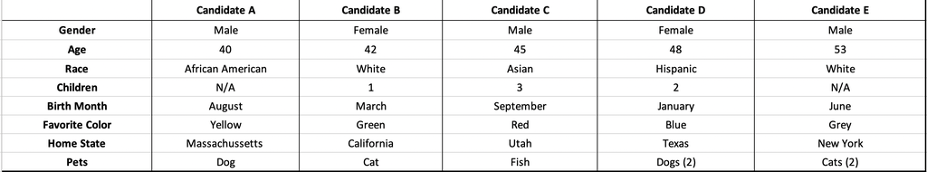

```r
#Import dataset for scores

responses = read.csv("https://raw.githubusercontent.com/prernaadvani/QTM-385-Final-Project/master/Social%20Choice%20(Responses)%20-%20Form%20Responses%201.csv")
responses
```

```
##   Person CandidateA CandidateB CandidateC CandidateD CandidateE
## 1      1         90         50         70         99         30
## 2      2         80         90         80         90         90
## 3      3         60         55         45         65         40
## 4      4         80         85         80        100         70
## 5      5         70         98         40        100         50
## 6      6         60         95         85         90         80
```

```r
#average score
sum(responses[,-1])/30
```

```
## [1] 73.9
```

```r
#Highest total
as.matrix(colSums(responses))
```

```
##            [,1]
## Person       21
## CandidateA  440
## CandidateB  473
## CandidateC  400
## CandidateD  544
## CandidateE  360
```

**Candidate D wins.**

### Social Welfare Functions

> Utilitarian/Benthamite Winner based on case study

```r
#Highest mean score
responses.mat = as.matrix(responses)
csprefs.avg = as.matrix(colMeans(responses.mat))
colnames(csprefs.avg) = "Average Score"
as.matrix(csprefs.avg[2:6,])
```

```
##                [,1]
## CandidateA 73.33333
## CandidateB 78.83333
## CandidateC 66.66667
## CandidateD 90.66667
## CandidateE 60.00000
```

**Candidate D wins.**

> Rawlsian Winner based on raw score

```r
#Winner is the candidate with the highest min score
csprefs.min = as.matrix(apply(responses.mat,2,min))
as.matrix(csprefs.min[2:6,])
```

```
##            [,1]
## CandidateA   60
## CandidateB   50
## CandidateC   40
## CandidateD   65
## CandidateE   30
```

**Candidate D wins.**

> Egalitarian Winner based on raw score

```r
#subtract max-min
#smallest distance wins
csprefs.max = as.matrix(apply(responses.mat,2,max))
as.matrix((csprefs.max - csprefs.min)[2:6,])
```

```
##            [,1]
## CandidateA   30
## CandidateB   48
## CandidateC   45
## CandidateD   35
## CandidateE   60
```

**Candidate A wins.**

### Electoral System Winners

> SMP

```r
responses.df = data.frame(responses.mat)
cssmp = as.matrix(colnames(responses.df)[apply(responses.df,1,which.max)])

table(cssmp[,1]=="CandidateA", dnn = "Candidate A Wins")
```

```
## Candidate A Wins
## FALSE
##     6
```

```r
table(cssmp[,1]=="CandidateB", dnn = "Candidate B Wins")
```

```
## Candidate B Wins
## FALSE  TRUE
##     4     2
```

```r
table(cssmp[,1]=="CandidateC", dnn = "Candidate C Wins")
```

```
## Candidate C Wins
## FALSE
##     6
```

```r
table(cssmp[,1]=="CandidateD", dnn = "Candidate D Wins")
```

```
## Candidate D Wins
## FALSE  TRUE
##     2     4
```

```r
table(cssmp[,1]=="CandidateE", dnn = "Candidate E Wins")
```

```
## Candidate E Wins
## FALSE
##     6
```

**Candidate D wins.**

> Borda Count

```r
#Create matrix with ranked preferences
responses.ranked = matrix(
  c(3,1,2,4,0,0,1,0,1,1,3,2,1,4,0,1,2,1,3,0,2,3,0,4,1,0,4,2,3,1),
  ncol = 5,
  nrow = 6,
  byrow = TRUE)
colnames(responses.ranked) = c("Candidate A","Candidate B", "Candidate C", "Candidate D", "Candidate E")
responses.ranked
```

```
##      Candidate A Candidate B Candidate C Candidate D Candidate E
## [1,]           3           1           2           4           0
## [2,]           0           1           0           1           1
## [3,]           3           2           1           4           0
## [4,]           1           2           1           3           0
## [5,]           2           3           0           4           1
## [6,]           0           4           2           3           1
```

```r
#Borda Count Winner
as.matrix(colSums((responses.ranked)))
```

```
##             [,1]
## Candidate A    9
## Candidate B   13
## Candidate C    6
## Candidate D   19
## Candidate E    3
```

**Candidate D wins.**

> Instant Runoff
- Looking at SMP data, we see that the following percent of people ranked each of the candidates first:
  - Candidate A = 0/6 = 0%
  - Candidate B = 2/6 = 33.34%
  - Candidate C = 0/6 = 0%
  - Candidate D = 4/6 = 66.67%
  - Candidate E = 0/6 = 0%
- Candidate D received >50% of the vote

**Candidate D wins.**